# NYPD Shooting

## NYPD Shooting Data

This document’s created to analyze NYPD Shooting Incident Data available through https://catalog.data.gov/dataset.

This Markdown uses **tidyverse** and **lubridate** R Packages.

The data is a list of every shooting incident that occurred in NYC going back to 2006 through the end of the previous calendar year.

importing data set and summarizing the data:

```r
NYPD_Shooting <- read_csv("https://data.cityofnewyork.us/api/views/833y-fsy8/rows.csv?accessType=DOWNLOAD")
```

```r
summary(NYPD_Shooting)
```

```
##   INCIDENT_KEY        OCCUR_DATE         OCCUR_TIME           BORO
##  Min.   :  9953245   Length:28562       Length:28562      Length:28562
##  1st Qu.: 65439914   Class :character   Class1:hms        Class :character
##  Median : 92711254   Mode  :character   Class2:difftime   Mode  :character
##  Mean   :127405824                      Mode  :numeric
##  3rd Qu.:203131993
##  Max.   :279758069
##
##  LOC_OF_OCCUR_DESC     PRECINCT     JURISDICTION_CODE LOC_CLASSFCTN_DESC
##  Length:28562       Min.   :  1.0   Min.   :0.0000    Length:28562
##  Class :character   1st Qu.: 44.0   1st Qu.:0.0000    Class :character
##  Mode  :character   Median : 67.0   Median :0.0000    Mode  :character
##                     Mean   : 65.5   Mean   :0.3219
##                     3rd Qu.: 81.0   3rd Qu.:0.0000
##                     Max.   :123.0   Max.   :2.0000
##                                     NA's   :2
##  LOCATION_DESC      STATISTICAL_MURDER_FLAG PERP_AGE_GROUP
##  Length:28562       Mode :logical           Length:28562
##  Class :character   FALSE:23036             Class :character
##  Mode  :character   TRUE :5526              Mode  :character
##
##
##
##
##    PERP_SEX          PERP_RACE         VIC_AGE_GROUP        VIC_SEX
##  Length:28562       Length:28562       Length:28562       Length:28562
##  Class :character   Class :character   Class :character   Class :character
##  Mode  :character   Mode  :character   Mode  :character   Mode  :character
##
##
##
##
##    VIC_RACE           X_COORD_CD        Y_COORD_CD        Latitude
##  Length:28562       Min.   : 914928   Min.   :125757   Min.   :40.51
##  Class :character   1st Qu.:1000068   1st Qu.:182912   1st Qu.:40.67
##  Mode  :character   Median :1007772   Median :194901   Median :40.70
##                     Mean   :1009424   Mean   :208380   Mean   :40.74
##                     3rd Qu.:1016807   3rd Qu.:239814   3rd Qu.:40.82
##                     Max.   :1066815   Max.   :271128   Max.   :40.91
##                                                        NA's   :59
##    Longitude        Lon_Lat
##  Min.   :-74.25   Length:28562
##  1st Qu.:-73.94   Class :character
##  Median :-73.92   Mode  :character
##  Mean   :-73.91
##  3rd Qu.:-73.88
##  Max.   :-73.70
##  NA's   :59
```

## Cleaning the data and changing datatypes

Also changing the Occur_date type to and other categorical column types to factors, summarizing the transformed data set:

```r
NYPD_Shooting <- NYPD_Shooting %>% select(-c(INCIDENT_KEY, OCCUR_TIME, X_COORD_CD, Y_COORD_CD, Latitude, Longitude, Lon_Lat)) %>% mutate(OCCUR_DATE = mdy(OCCUR_DATE), BORO = as.factor(BORO), LOC_OF_OCCUR_DESC = as.factor(LOC_OF_OCCUR_DESC), LOC_CLASSFCTN_DESC = as.factor(LOC_CLASSFCTN_DESC), LOCATION_DESC = as.factor(LOCATION_DESC), PERP_AGE_GROUP = as.factor(PERP_AGE_GROUP), PERP_SEX = as.factor(PERP_SEX), PERP_RACE = as.factor(PERP_RACE), VIC_AGE_GROUP=as.factor(VIC_AGE_GROUP), VIC_SEX=as.factor(VIC_SEX), VIC_RACE = as.factor(VIC_RACE), JURISDICTION_CODE=as.factor(JURISDICTION_CODE), PRECINCT = as.factor(PRECINCT))
```

```r
summary(NYPD_Shooting)
```

```
##    OCCUR_DATE                    BORO       LOC_OF_OCCUR_DESC    PRECINCT
##  Min.   :2006-01-01   BRONX        : 8376   INSIDE :  460     75     : 1628
##  1st Qu.:2009-09-04   BROOKLYN     :11346   OUTSIDE: 2506     73     : 1500
##  Median :2013-09-20   MANHATTAN    : 3762   NA's   :25596     67     : 1259
##  Mean   :2014-06-07   QUEENS       : 4271                     44     : 1076
##  3rd Qu.:2019-09-29   STATEN ISLAND:  807                     79     : 1045
##  Max.   :2023-12-29                                           47     : 1006
##                                                               (Other):21048
##  JURISDICTION_CODE  LOC_CLASSFCTN_DESC                   LOCATION_DESC
##  0   :23923        STREET    : 1886    MULTI DWELL - PUBLIC HOUS: 5007
##  1   :   81        HOUSING   :  460    MULTI DWELL - APT BUILD  : 2964
##  2   : 4556        DWELLING  :  243    (null)                   : 1711
##  NA's:    2        COMMERCIAL:  208    PVT HOUSE                :  983
##                    OTHER     :   59    GROCERY/BODEGA           :  750
##                    (Other)   :  110    (Other)                  : 2170
##                    NA's      :25596    NA's                     :14977
##  STATISTICAL_MURDER_FLAG PERP_AGE_GROUP   PERP_SEX              PERP_RACE
##  Mode :logical           18-24  :6438   (null): 1141   BLACK         :11903
##  FALSE:23036             25-44  :6041   F     :  444   WHITE HISPANIC: 2510
##  TRUE :5526              UNKNOWN:3148   M     :16168   UNKNOWN       : 1837
##                          <18    :1682   U     : 1499   BLACK HISPANIC: 1392
##                          (null) :1141   NA's  : 9310   (null)        : 1141
##                          (Other): 768                  (Other)       :  469
##                          NA's   :9344                  NA's          : 9310
##  VIC_AGE_GROUP   VIC_SEX                             VIC_RACE
##  <18    : 2954   F: 2760   AMERICAN INDIAN/ALASKAN NATIVE:   11
##  1022   :    1   M:25790   ASIAN / PACIFIC ISLANDER      :  440
##  18-24  :10384   U:   12   BLACK                         :20235
##  25-44  :12973             BLACK HISPANIC                : 2795
##  45-64  : 1981             UNKNOWN                       :   70
##  65+    :  205             WHITE                         :  728
##  UNKNOWN:   64             WHITE HISPANIC                : 4283
```

## Visualizations & Analysis

Now let’s take a first look at the overall shooting incidents trend from 2006:

```r
NYPD_Shooting_grouped_by_year <- NYPD_Shooting %>% mutate(year = year(OCCUR_DATE)) %>% group_by(year) %>% summarize(shooting_count = n())  %>% ungroup()
```

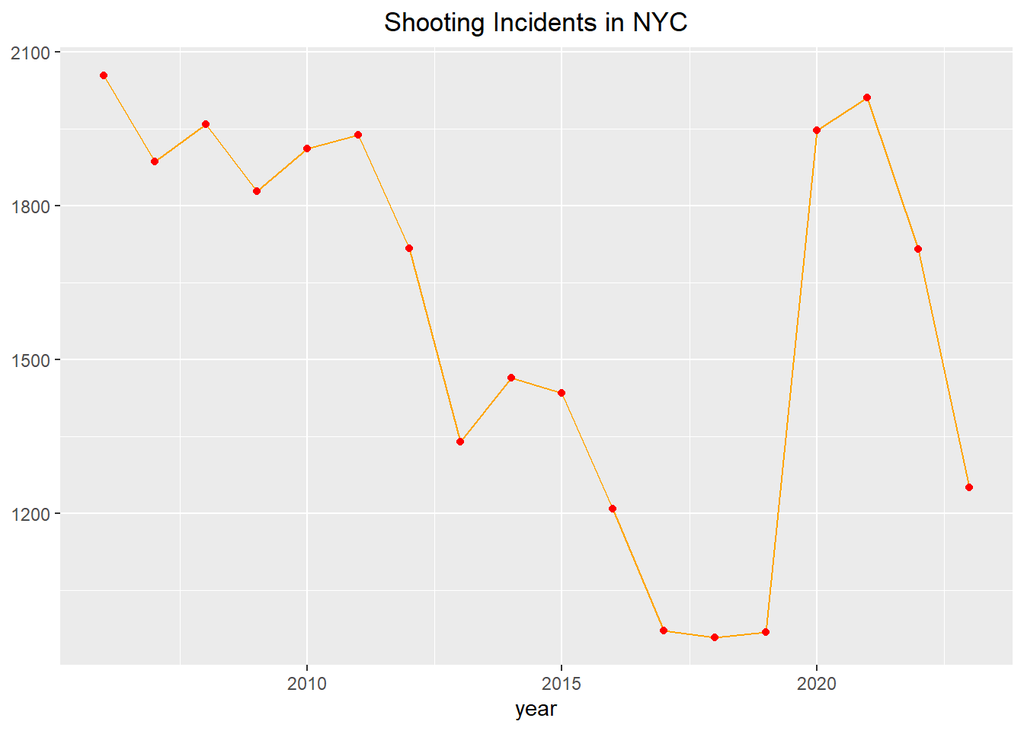

```r
NYPD_Shooting_grouped_by_year %>% ggplot(aes(x = year, y = shooting_count)) + geom_line(color = "orange") + geom_point(color = "red")+ labs(title = "Shooting Incidents in NYC", y = NULL) + theme(plot.title = element_text(hjust = 0.5))
```

As can be seen there was an overall drop starting from 2012 which continued till the year 2020 when the numbers rose to the previous high-levels followed by the downward trend after 2021.

Now let’s take a look at different boroughs where the shooting incident occurred:

```r
NYPD_Shooting_grouped_by_yearBorough <- NYPD_Shooting %>% mutate(year = year(OCCUR_DATE)) %>% group_by(year, BORO) %>% summarize(shooting_count = n())  %>% ungroup()
```

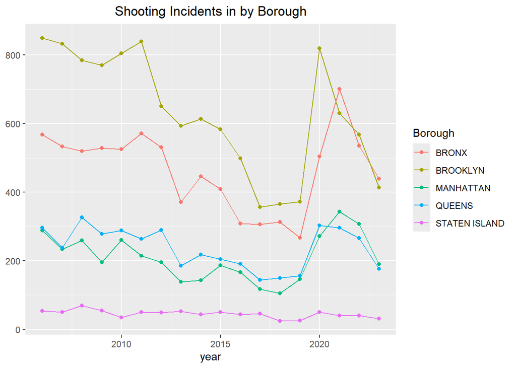

```r
NYPD_Shooting_grouped_by_yearBorough %>% ggplot(aes(x = year, y = shooting_count, color = BORO)) + geom_line() + geom_point() + labs(title = "Shooting Incidents in by Borough", y = NULL, color = "Borough") + theme(plot.title = element_text(hjust = 0.5))
```

as can be seen from the data of the Incidents by Borough, all boroughs follow the same trend seen overall for NYC. Brooklyn and Bronx have the highest numbers over the years with Staten Island remaining stable and under 100 over the years.

## Sources of Bias

I’ve not used the perpetrator and victim race in my analysis which could lead to racial profiling and bias as based on the demographics in each borough it might lead to incorrect generalizations and errors.

## Model

```r
mod <- lm(shooting_count ~ year, data = NYPD_Shooting_grouped_by_year)
```

```r
summary(mod)
```

```
##
## Call:
## lm(formula = shooting_count ~ year, data = NYPD_Shooting_grouped_by_year)
##
## Residuals:
##    Min     1Q Median     3Q    Max
## -529.6 -260.1   40.9  171.0  650.8
##
## Coefficients:
##             Estimate Std. Error t value Pr(>|t|)
## (Intercept) 71821.94   32419.87   2.215   0.0416 *
## year          -34.86      16.09  -2.166   0.0457 *
## ---
## Signif. codes:  0 '***' 0.001 '**' 0.01 '*' 0.05 '.' 0.1 ' ' 1
##
## Residual standard error: 354.2 on 16 degrees of freedom
## Multiple R-squared:  0.2268, Adjusted R-squared:  0.1785
## F-statistic: 4.693 on 1 and 16 DF,  p-value: 0.04572
```

## Conclusion

In this report we have taken a look at the Shooting Incidents registered by NYPD for NYC since 2006. We have looked at the trends and have discovered periods of low shootings before rising again around 2020 and then continuing the downward trend as observed in 2010s. We then took a closer look at the Incidents by Borough, all boroughs follow the same trend seen overall for NYC. Brooklyn and Bronx have the highest numbers over the years with Staten Island remaining stable and under 100 over the years. We have then developed a model for shooting count as a function of year, for an estimate of the resources needed for NYPD to better handle these shooting Incidents.